# Act Math by High School GPA

2025-10-16

**PURPOSE:** This report contains visualizations describing math performance for first time freshman in their first math courses. It includes heat maps of enrollment and performance by ACT math test scores and high school GPA. It does not contain the results of any predictive model.

### Data

This displays all years of available data (Fall 2005 to Fall 2024.)

The first term that a first time freshman took a math course was determined. Then, all math courses in that term were extracted.

Next, the following filters are applied:

- High school GPA values of zero are removed.
- Rare, missing, and withdraw grades (“missing”, “V”, “I”, “NC”, “CR”, “W”, NA) are removed.
- Students with more than the 99th percentile in course load (19 credits) are removed.
- Math courses taken before half a year before the cohort date (yr_diff < -0.5) are removed. This allows for taking math classes the summer before the fall cohort date.
- Students aged less than 12 are removed.
- All courses greater than 3000 are removed.
- Classes that were not offered after 2021 are removed.

### Enrollment by course

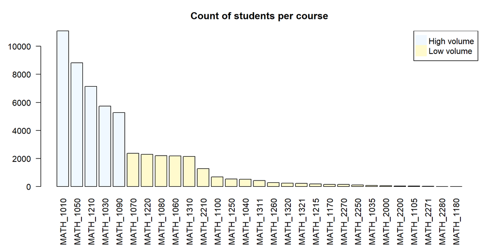

### ACT math scores appear to have guided course selection

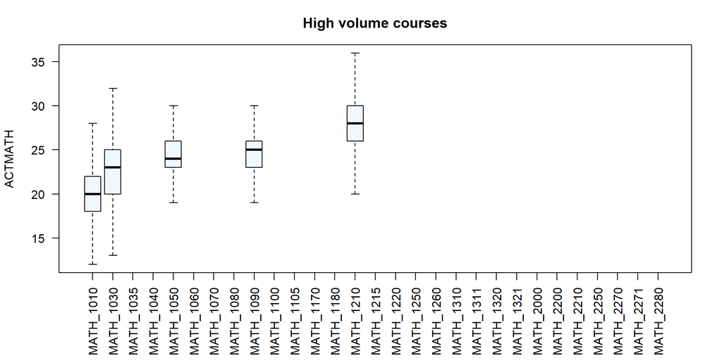

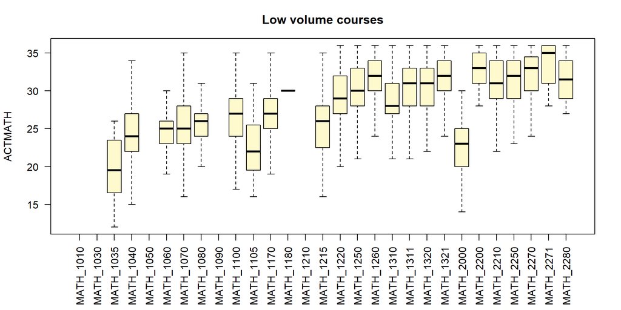

### ACT math scores per course over time

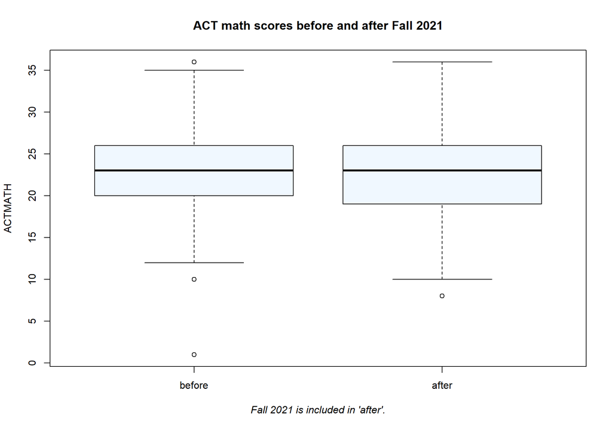

[figure not shown]

[figure not shown]

### Grade distribution per course

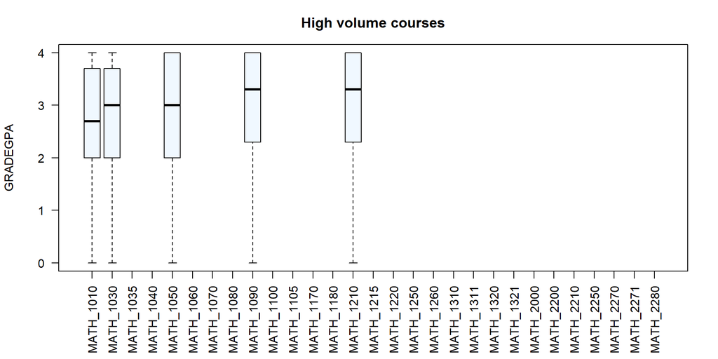

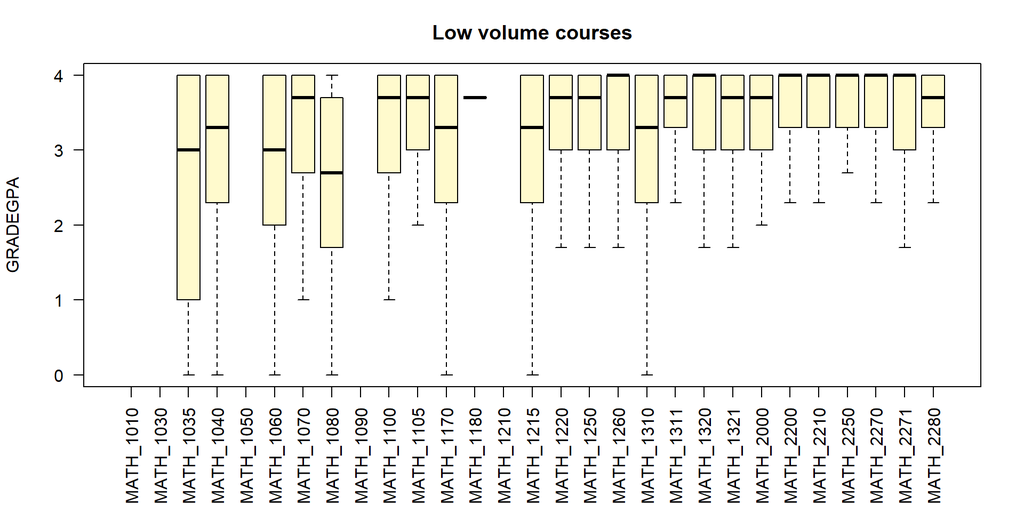

### High school GPA and math grades

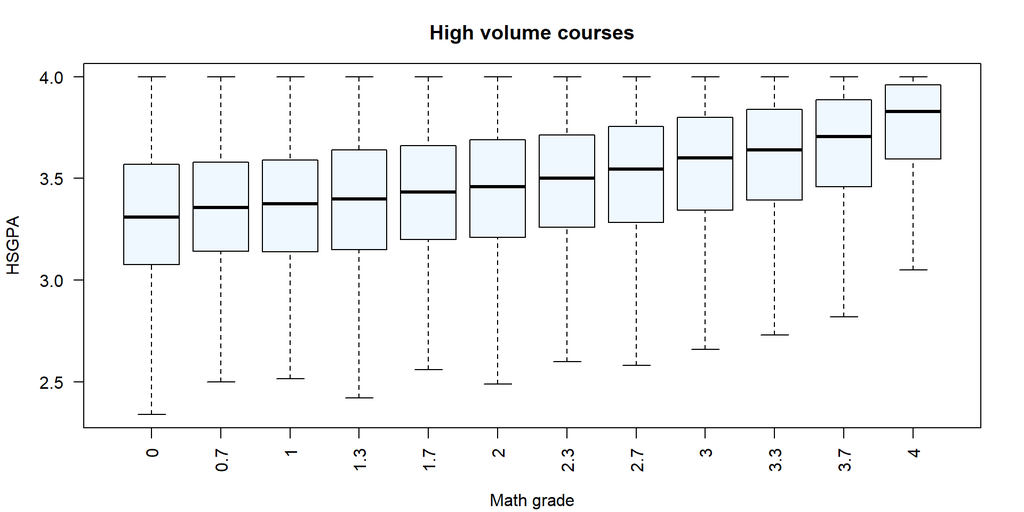

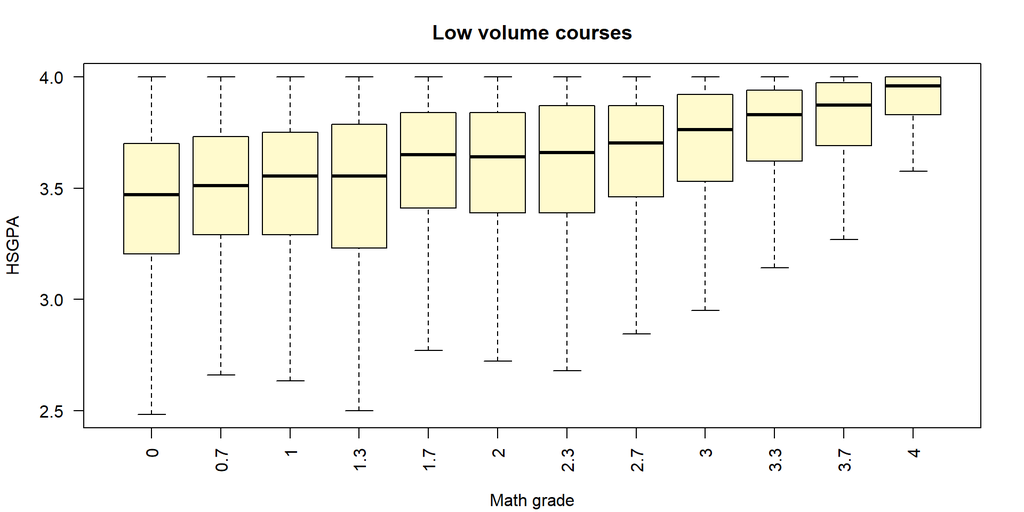

### Course load and math grades

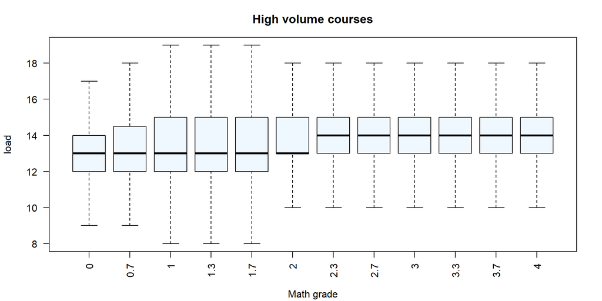

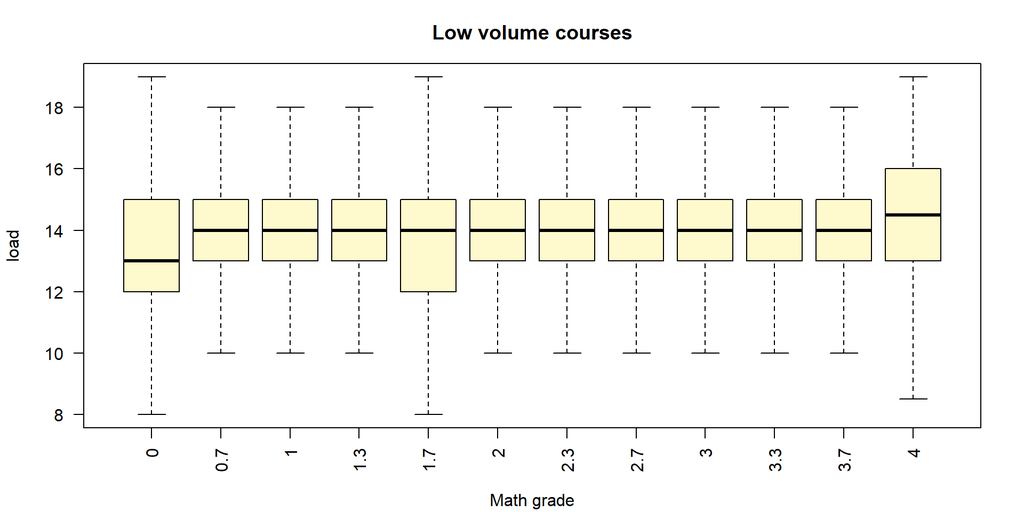

### Year to math (yr_diff) and math grades

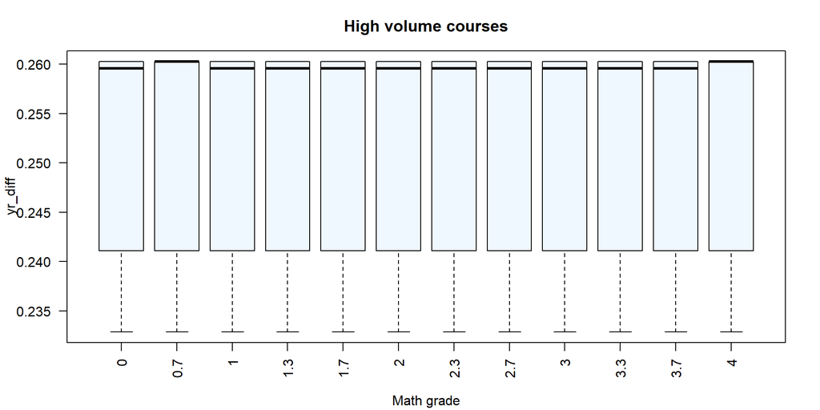

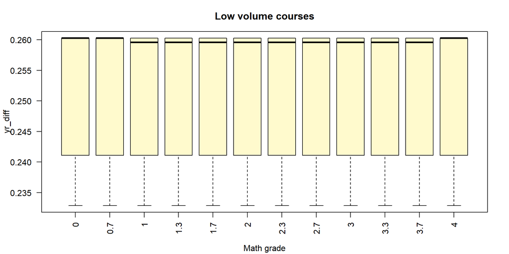

### Heatmaps

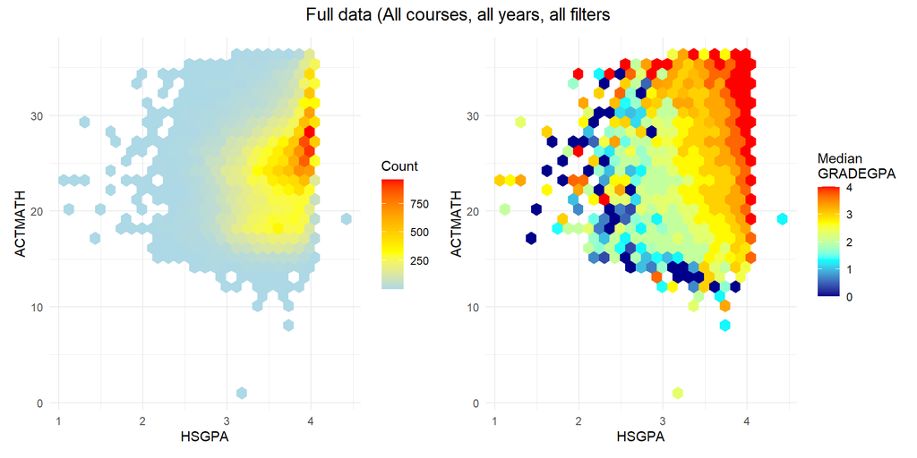

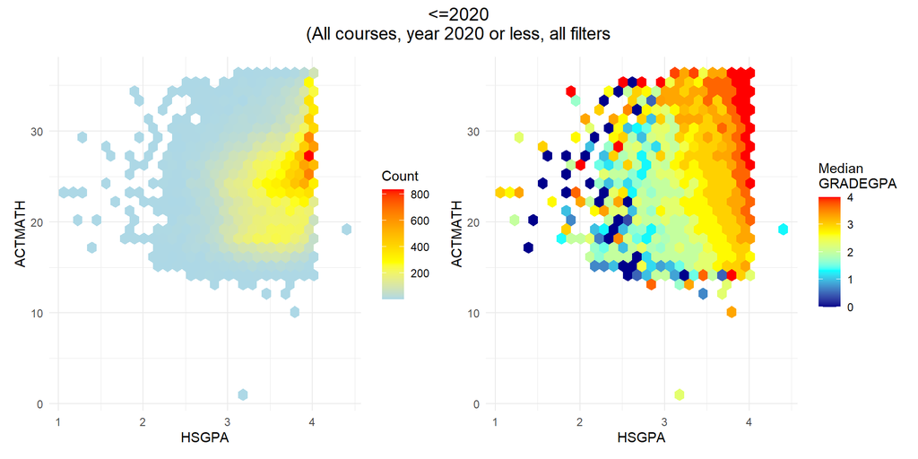

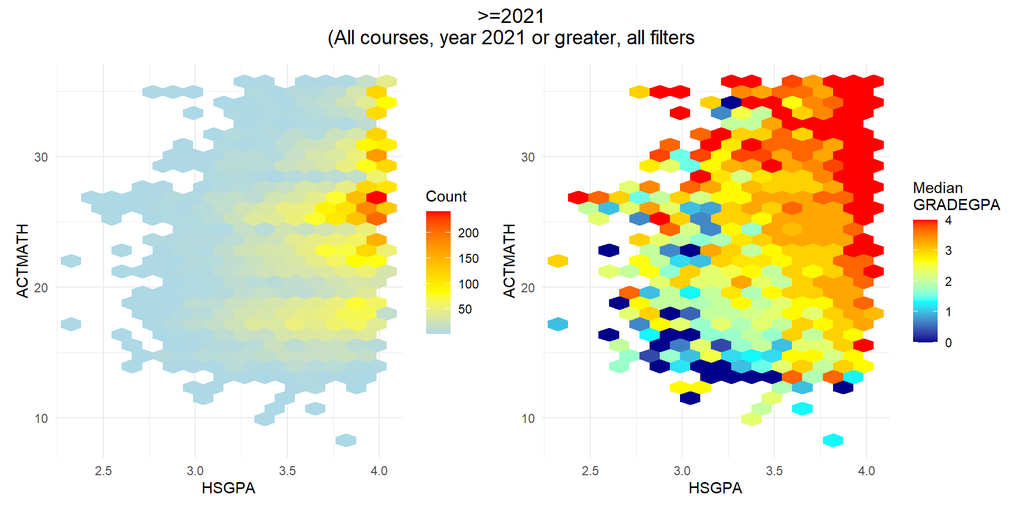

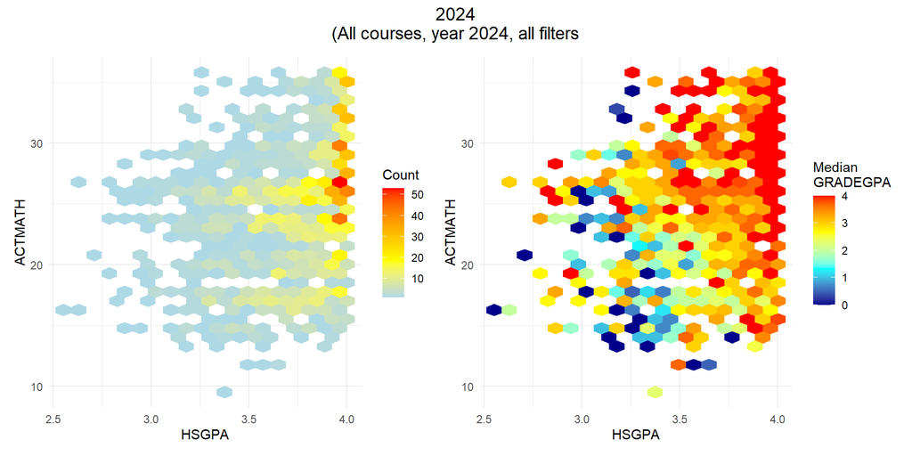

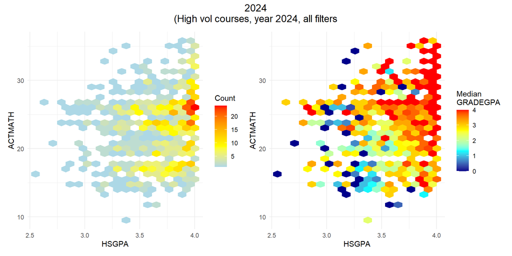

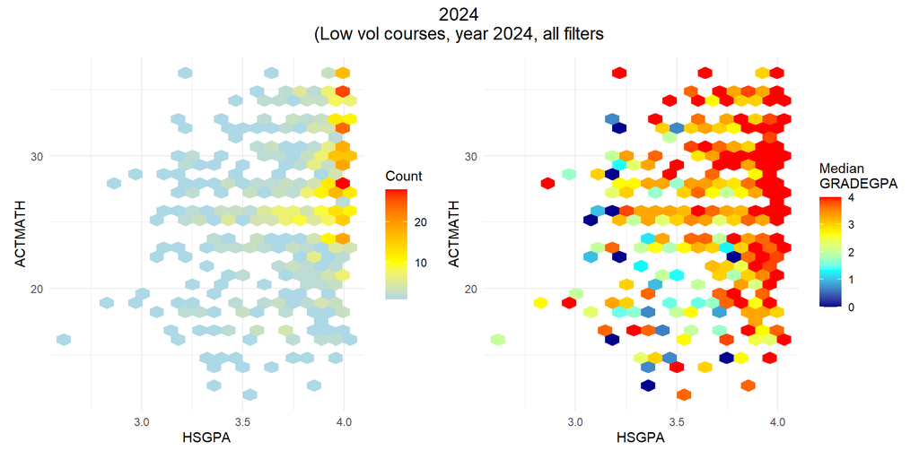

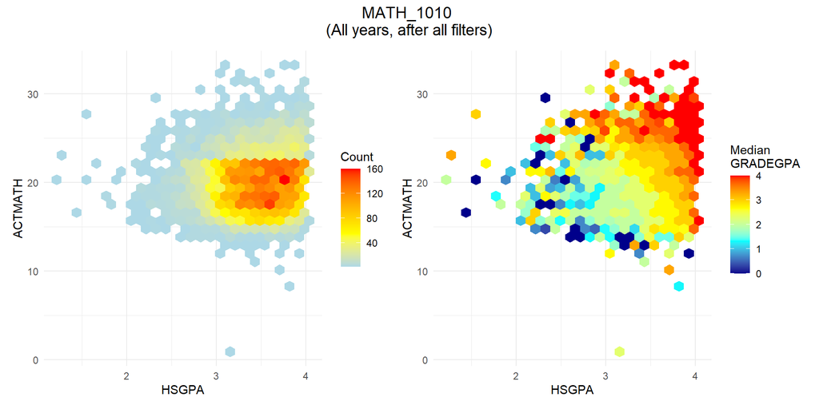

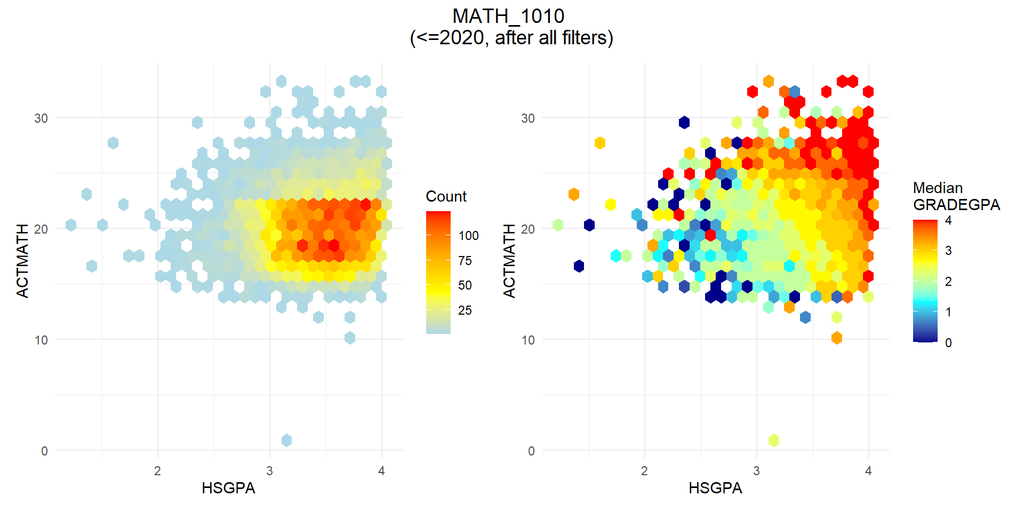

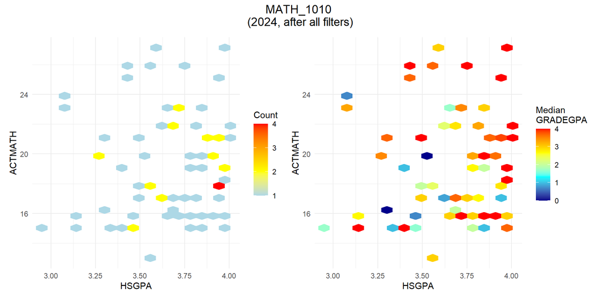

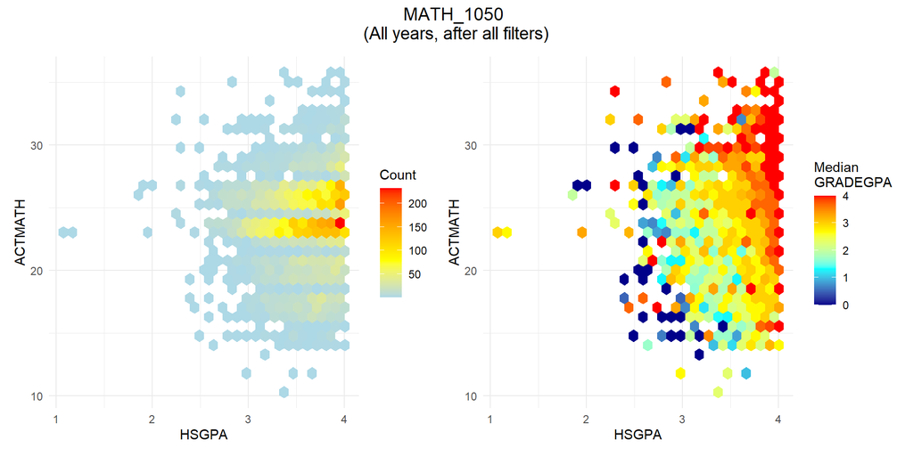

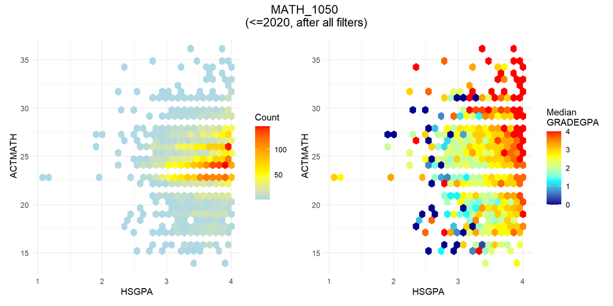

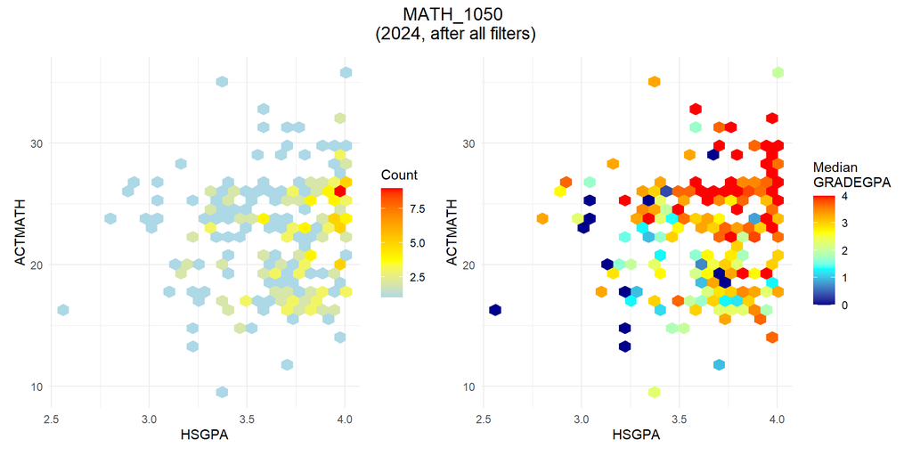

[9 more figures not shown]

Data summary

| Name | cleanData |
| --- | --- |
| Number of rows | 54355 |
| Number of columns | 161 |
| _______________________ |  |
| Column type frequency: |  |
| character | 119 |
| factor | 4 |
| logical | 1 |
| numeric | 33 |
| POSIXct | 4 |
| ________________________ |  |
| Group variables | None |

**Variable type: character**

| skim_variable | n_missing | complete_rate | min | max | empty | n_unique | whitespace |
| --- | --- | --- | --- | --- | --- | --- | --- |
| TERM | 0 | 1.00 | 4 | 4 | 0 | 61 | 0 |
| EMPLID | 0 | 1.00 | 8 | 8 | 0 | 53944 | 0 |
| class | 0 | 1.00 | 18 | 18 | 0 | 3790 | 0 |
| TITLE | 0 | 1.00 | 4 | 23 | 0 | 34 | 0 |
| SECTION | 0 | 1.00 | 3 | 3 | 0 | 46 | 0 |
| GRADE | 0 | 1.00 | 1 | 2 | 0 | 13 | 0 |
| INSTEMPLID | 0 | 1.00 | 8 | 8 | 0 | 650 | 0 |
| INSTNAME | 0 | 1.00 | 6 | 35 | 0 | 673 | 0 |
| ACADYR | 0 | 1.00 | 9 | 9 | 0 | 21 | 0 |
| TERMEXTRACT | 0 | 1.00 | 1 | 1 | 0 | 2 | 0 |
| MAX_SNAP | 0 | 1.00 | 3 | 3 | 0 | 1 | 0 |
| FULLNAME | 5320 | 0.90 | 5 | 47 | 0 | 48623 | 0 |
| STUDENTCAREER | 0 | 1.00 | 1 | 1 | 0 | 2 | 0 |
| SUBJECT_CD | 0 | 1.00 | 4 | 4 | 0 | 1 | 0 |
| SUBJECT_NAME | 0 | 1.00 | 11 | 11 | 0 | 1 | 0 |
| SUBJECT_LONG | 0 | 1.00 | 11 | 11 | 0 | 1 | 0 |
| SUBJECT_ACAD_ORG_CD | 0 | 1.00 | 4 | 4 | 0 | 1 | 0 |
| CLASSNBR | 0 | 1.00 | 4 | 5 | 0 | 2850 | 0 |
| OFFERINGNBR | 0 | 1.00 | 1 | 1 | 0 | 1 | 0 |
| SESSIONCODE | 0 | 1.00 | 1 | 1 | 0 | 5 | 0 |
| COURSECAREER | 0 | 1.00 | 1 | 1 | 0 | 1 | 0 |
| SCHEDFLAG | 0 | 1.00 | 1 | 1 | 0 | 2 | 0 |
| WAUTOENRL | 0 | 1.00 | 1 | 1 | 0 | 2 | 0 |
| AUTOENROLL | 0 | 1.00 | 1 | 1 | 0 | 1 | 0 |
| COMPONENT | 0 | 1.00 | 3 | 3 | 0 | 1 | 0 |
| GENED | 12494 | 0.77 | 2 | 4 | 0 | 5 | 0 |
| VARCREDIT | 0 | 1.00 | 1 | 1 | 0 | 1 | 0 |
| CONTRACT | 0 | 1.00 | 1 | 1 | 0 | 2 | 0 |
| DIRECTPAY | 0 | 1.00 | 1 | 1 | 0 | 2 | 0 |
| CORRESPONDENCE | 0 | 1.00 | 1 | 1 | 0 | 2 | 0 |

[output cut: 89 more lines]

**Variable type: factor**

| skim_variable | n_missing | complete_rate | ordered | n_unique | top_counts |
| --- | --- | --- | --- | --- | --- |
| course | 0 | 1 | FALSE | 29 | MAT: 11103, MAT: 8828, MAT: 7138, MAT: 5740 |
| age_cut | 0 | 1 | FALSE | 5 | (17: 44080, (18: 5125, (0,: 2364, (19: 2357 |
| cleanGrade | 0 | 1 | FALSE | 13 | A: 15865, B: 6483, A_m: 5937, B_p: 5194 |
| covid | 0 | 1 | FALSE | 2 | bef: 38001, aft: 16354 |

**Variable type: logical**

| skim_variable | n_missing | complete_rate | mean | count |
| --- | --- | --- | --- | --- |
| minTerm | 0 | 1 | 1 | TRU: 54355 |

**Variable type: numeric**

| skim_variable | n_missing | complete_rate | mean | sd | p0 | p25 | p50 | p75 | p100 | hist |
| --- | --- | --- | --- | --- | --- | --- | --- | --- | --- | --- |
| CATNBR | 0 | 1.00 | 1129.19 | 212.40 | 1010.00 | 1030.00 | 1060.00 | 1210.00 | 2280.00 | ▇▁▁▁▁ |
| UNITS | 0 | 1.00 | 3.67 | 0.56 | 2.00 | 3.00 | 4.00 | 4.00 | 5.00 | ▁▅▁▇▁ |
| GRADEGPA | 0 | 1.00 | 2.84 | 1.22 | 0.00 | 2.00 | 3.00 | 4.00 | 4.00 | ▂▁▂▃▇ |
| ALT_ID | 0 | 1.00 | 893105.30 | 408453.62 | 2533.00 | 584827.00 | 936687.00 | 1226998.00 | 1593015.00 | ▃▅▇▇▆ |
| CATNBR2 | 0 | 1.00 | 1129.19 | 212.40 | 1010.00 | 1030.00 | 1060.00 | 1210.00 | 2280.00 | ▇▁▁▁▁ |
| FISCAL_YEAR_OF_STARTDT | 0 | 1.00 | 2017.18 | 5.75 | 2005.00 | 2013.00 | 2018.00 | 2022.00 | 2025.00 | ▃▅▅▆▇ |
| ROLLUP_SORT_ORDER | 0 | 1.00 | 866.00 | 0.00 | 866.00 | 866.00 | 866.00 | 866.00 | 866.00 | ▁▁▇▁▁ |
| CONTACTMINUTES | 16752 | 0.69 | 2365.73 | 1308.06 | 0.00 | 2150.00 | 2880.00 | 3200.00 | 5800.00 | ▃▁▇▂▁ |
| USHE_ACADYR | 0 | 1.00 | 2017.21 | 5.74 | 2006.00 | 2013.00 | 2018.00 | 2022.00 | 2026.00 | ▆▆▆▇▇ |
| USHE_TERM | 0 | 1.00 | 2.13 | 0.40 | 1.00 | 2.00 | 2.00 | 2.00 | 3.00 | ▁▁▇▁▂ |
| TERM2 | 0 | 1.00 | 1170.93 | 57.38 | 1056.00 | 1128.00 | 1178.00 | 1218.00 | 1256.00 | ▃▅▅▆▇ |
| CLASSENROLLMENTCAPACITY | 22838 | 0.58 | 92.23 | 42.89 | 2.00 | 60.00 | 80.00 | 120.00 | 285.00 | ▂▇▃▁▁ |
| ROOM_MAX_1 | 37556 | 0.31 | 239.06 | 307.54 | 0.00 | 86.00 | 102.00 | 202.00 | 999.00 | ▇▂▁▁▂ |
| ROOM_MAX_2 | 54058 | 0.01 | 396.17 | 296.80 | 24.00 | 203.00 | 348.00 | 348.00 | 999.00 | ▇▆▁▁▃ |
| ROOM_MAX_3 | 54355 | 0.00 | NaN | NA | NA | NA | NA | NA | NA |  |
| TERM_NBR | 0 | 1.00 | 3.25 | 0.81 | 1.00 | 3.00 | 3.00 | 3.00 | 5.00 | ▁▁▇▁▂ |
| FA_PELL | 0 | 1.00 | 0.20 | 0.40 | 0.00 | 0.00 | 0.00 | 0.00 | 1.00 | ▇▁▁▁▂ |
| AGE | 0 | 1.00 | 18.20 | 0.84 | 14.00 | 18.00 | 18.00 | 18.00 | 58.00 | ▇▁▁▁▁ |
| APCREDIT | 0 | 1.00 | 6.77 | 12.00 | 0.00 | 0.00 | 0.00 | 9.00 | 89.00 | ▇▁▁▁▁ |
| HSGPA | 0 | 1.00 | 3.60 | 0.34 | 0.68 | 3.38 | 3.68 | 3.90 | 4.42 | ▁▁▁▇▇ |
| HONORS | 0 | 1.00 | 0.14 | 0.35 | 0.00 | 0.00 | 0.00 | 0.00 | 1.00 | ▇▁▁▁▁ |
| ACTCOMP | 13794 | 0.75 | 25.07 | 4.36 | 10.00 | 22.00 | 25.00 | 28.00 | 36.00 | ▁▃▇▆▂ |
| ACTENGL | 13382 | 0.75 | 24.85 | 5.30 | 7.00 | 21.00 | 24.00 | 29.00 | 36.00 | ▁▂▇▆▃ |
| ACTMATH | 13382 | 0.75 | 24.46 | 4.65 | 1.00 | 21.00 | 24.00 | 27.00 | 36.00 | ▁▁▅▇▂ |
| ACTSCI | 13390 | 0.75 | 24.96 | 4.57 | 2.00 | 22.00 | 24.00 | 28.00 | 36.00 | ▁▁▅▇▂ |
| load | 0 | 1.00 | 13.79 | 2.19 | 2.00 | 13.00 | 14.00 | 15.00 | 19.00 | ▁▁▂▇▂ |
| cohort_year | 0 | 1.00 | 2016.03 | 5.80 | 2005.00 | 2011.00 | 2017.00 | 2021.00 | 2024.00 | ▃▅▅▆▇ |
| class_year | 0 | 1.00 | 2016.36 | 5.74 | 2005.00 | 2012.00 | 2017.00 | 2021.00 | 2025.00 | ▅▅▆▇▇ |
| yr_diff | 0 | 1.00 | 0.47 | 0.72 | -0.40 | 0.24 | 0.26 | 0.26 | 16.64 | ▇▁▁▁▁ |
| course_level | 0 | 1.00 | 1.03 | 0.17 | 1.00 | 1.00 | 1.00 | 1.00 | 2.00 | ▇▁▁▁▁ |
| grade_binary | 0 | 1.00 | 0.85 | 0.36 | 0.00 | 1.00 | 1.00 | 1.00 | 1.00 | ▂▁▁▁▇ |
| grade_trinary | 0 | 1.00 | 1.54 | 0.74 | 0.00 | 1.00 | 2.00 | 2.00 | 2.00 | ▂▁▂▁▇ |
| grade_quad | 0 | 1.00 | 1.83 | 1.01 | 0.00 | 1.00 | 2.00 | 3.00 | 3.00 | ▃▃▁▇▆ |

**Variable type: POSIXct**

| skim_variable | n_missing | complete_rate | min | max | median | n_unique |
| --- | --- | --- | --- | --- | --- | --- |
| EOTDATE | 0 | 1.00 | 2005-08-03 | 2025-08-01 | 2017-12-15 | 61 |
| CENSUSDATE | 0 | 1.00 | 2005-06-06 | 2025-06-02 | 2017-09-11 | 61 |
| ORG_EFFDT | 25771 | 0.53 | 2005-08-05 | 2018-04-15 | 2012-12-31 | 39 |
| COHORT_DT | 0 | 1.00 | 2005-09-14 | 2024-09-09 | 2017-09-11 | 20 |